# Notes 4 - Exploratory Data Analysis

Linda Kukolich

January 26, 2015

Case Study in clustering - Uses the Smartphones data we had for a project in Getting and Cleaning Data.

The data has been processed, converting raw numbers to more “pure” numbers with respect to the physics. Plus, the data was windowed and various measures (mean, std, max) were calculated

Samsung Galaxy data

```
load("data/samsungData.rda")
# tBodyAcc-{mean,std,mad,max}()-{X,Y,Z}
names(samsungData)[1:12]
# laying, sitting, standing, walk, walkdown, walkup
table(samsungData$activity)
```

Plotting average acceleration (X, Y) for first subject

```
par(mfrow = c(1, 2), mar = c(5, 4, 1, 1))
samsungData <- transform(samsungData, activity = factor(activity))
sub1 <- subset(samsungData, subject == 1)
#mean-X
plot(sub1[, 1], col = sub1$activity, ylab = names(sub1)[1])
# mean-Y
plot(sub1[, 1], col=sub1$activity, ylab = names(sub1)[2])
legend("bottomright", legend = unique(sub1$activity), col = unique(sub1$activity), pch = 1)
```

```
source("myplclust.R")
distanceMatrix <- dist(sub1[,1:3])
hclustering <- hclust(distanceMatrix)
myplclust(hclustering, lab.col = unclass(sub1$activity))
```

```
par(mfrow = c(1, 2))
plot(sub1[,10], pch = 19, col = sub1$activity, ylab = names(sub1)[10])
plot(sub1[,11], pch = 19, col = sub1$activity, ylab = names(sub1)[11])
```

```
source("myplclust.r")
distanceMatrix <- dist(sub1[, 10:12])
hclustering <- hclust(distanceMatrix)
myplclust(hclustering, lab.col = unclass(sub1$activity))
```

Singular Value Decomposition

```
# Leave off subject and activity labels, tacked onto the end
svd1 <- svd(scale(sub1[, -c(562, 563)]))
par(mfrow = c(1, 2))
plot(svd1$u[, 1], col = sub1$activity, pch = 19)
plot(svd1$u[, 2], col = sub1$activity, pch = 19)
```

Find maximum contributor, the element of the original data that has the maximum weight in the SVD vector. Then cluster based on that element.

```
plot(svd1$v[,2], pch = 19)
# Find the feature that contributes most
maxContrib <- which.max(svd$v[, 2])
# cluster based on max acceleration plus that feature
distanceMatrix <- dist(sub1[, c(10:12, maxContrib)])
# Then cluster
hclustering <- hclust(distanceMatrix)
# separates the 3 movement activities, but not the non-moving activities
myplclust(hclustering, lab.col = unclass(sub1$activity))
names(samsungData)[maxContrib] # fBodyAdd.meanFreq...Z
```

Try K-means. Ususally you want nstart to be bigger than 1, so you can try multiple initial conditions in hopes of coming across a better solution with one of them.

```
# K-means clustering (nstart = 1, first try)
kClust <- kmeans(sub1[, -c(562, 563)], centers = 6)
table(kClust$cluster, sub1$activity)
# nstart=1, second try
kClust <- kmeans(sub1[, -c(562, 563)], centers = 6, nstart = 1)
table(kClust$cluster, sub1$activity)
# nstart = 100, first try
kClust <- kmeans(sub1[, -c(562, 563)], centers = 6, nstart = 100)
table(kClust$cluster, sub1$activity)
# nstart=100, second try
kClust <- kmeans(sub1[, -c(562, 563)], centers = 6, nstart = 1)
```

What features provide the most information to discriminate between activities?

```
# cluster 1 variable centers (laying)
# First 2 elements high, others low
plot(kClust$center[1, 1:10], pch = 19, ylab = "Cluster Center", xlab = "")
table(kClust$cluster, sub1$activity)
# cluster 2 variable centers (walking)
# Different elements are high than were high for laying
plot(kClust$center[4, 1:10], pch = 19, ylab = "Cluster Center", xlab = "")
table(kClust$cluster, sub1$activity)
```

Clustering can help identify which features will be most helpful, which classes are more able to be distinguished. Helps guide where to put your energy moving forward.

# Air Pollution Case Study

1. Asking the question

You need to start with a basic question.

US-EPA Air pollution data [EPA Air Quality System (AQS) data for download](http://www.epa.gov/ttn/airs/airsaqs/detaildata/downloadaqsdata.htm)

```r
url1999 <- "http://www.epa.gov/ttn/airs/airsaqs/detaildata/501files/RD_501_88101_1999.zip"
url2013 <- "http://www.epa.gov/ttn/airs/airsaqs/detaildata/501files/RD_501_88101_2013.zip"
zip1999 <- "./data/RD_501_88101_1999.zip"
zip2013 <- "./data/Rd_501_88101_2013.zip"
data1999 <- "./data/RD_501_88101_1999-0.txt"
data2013 <- "./data/RD_501_88101_2013-0.txt"
```

[PM2.5 2013](http://www.epa.gov/ttn/airs/airsaqs/detaildata/501files/RD_501_88101_1999.zip) PM2.5 1999

## Opening up and exploring data files

```r
if (!file.exists("./data")) dir.create("./data")
if (!file.exists(zip1999)){
    download.data(url1999)
    print(paste("Data Downloaded on", date()))
}
if(!file.exists(zip2013)) {
    download.data(url2013)
    print(paste("Data Downloaded on", date()))
}
if (!file.exists(data1999)) unzip(zip1999)
if (!file.exists(data2013)) unzip(zip2013)
```

```r
# Header - 2 lines, it looks like there are two different numbers of columns
# BUT, only RD records are in either file, so no prob
# Separator - |
# RD|Action Code|State Code|County Code|Site ID|Parameter|POC|Sample Duration|Unit|Method|Date|Start Time|Sample Value|Null Data Code|Sampling Frequency|Monitor Protocol (MP) ID|Qualifier - 1|Qualifier - 2|Qualifier - 3|Qualifier - 4|Qualifier - 5|Qualifier - 6|Qualifier - 7|Qualifier - 8|Qualifier - 9|Qualifier - 10|Alternate Method Detectable Limit|Uncertainty
pm_1999 <- read.table(data1999, comment.char="#", header=FALSE, sep = "|", na.strings="")
cnames <- readLines(data1999, 1)
cnames
```

```
## [1] "# RD|Action Code|State Code|County Code|Site ID|Parameter|POC|Sample Duration|Unit|Method|Date|Start Time|Sample Value|Null Data Code|Sampling Frequency|Monitor Protocol (MP) ID|Qualifier - 1|Qualifier - 2|Qualifier - 3|Qualifier - 4|Qualifier - 5|Qualifier - 6|Qualifier - 7|Qualifier - 8|Qu…
```

```r
cnames <- strsplit(cnames, "|", fixed=TRUE)
cnames
```

```
## [[1]]
##  [1] "# RD"
##  [2] "Action Code"
##  [3] "State Code"
##  [4] "County Code"
##  [5] "Site ID"
##  [6] "Parameter"
##  [7] "POC"
##  [8] "Sample Duration"
##  [9] "Unit"
## [10] "Method"
## [11] "Date"
## [12] "Start Time"
## [13] "Sample Value"
## [14] "Null Data Code"
## [15] "Sampling Frequency"
## [16] "Monitor Protocol (MP) ID"
## [17] "Qualifier - 1"
## [18] "Qualifier - 2"
## [19] "Qualifier - 3"
## [20] "Qualifier - 4"
## [21] "Qualifier - 5"
## [22] "Qualifier - 6"
## [23] "Qualifier - 7"
## [24] "Qualifier - 8"
## [25] "Qualifier - 9"
## [26] "Qualifier - 10"
## [27] "Alternate Method Detectable Limit"
## [28] "Uncertainty"
```

```r
# Replace the spaces with dots
names(pm_1999) <- make.names(cnames[[1]])
head(pm_1999)
```

```
##   X..RD Action.Code State.Code County.Code Site.ID Parameter POC
## 1    RD           I          1          27       1     88101   1
## 2    RD           I          1          27       1     88101   1
## 3    RD           I          1          27       1     88101   1
## 4    RD           I          1          27       1     88101   1
## 5    RD           I          1          27       1     88101   1
## 6    RD           I          1          27       1     88101   1
##   Sample.Duration Unit Method     Date Start.Time Sample.Value
## 1               7  105    120 19990103      00:00           NA
## 2               7  105    120 19990106      00:00           NA
## 3               7  105    120 19990109      00:00           NA
## 4               7  105    120 19990112      00:00        8.841
## 5               7  105    120 19990115      00:00       14.920
## 6               7  105    120 19990118      00:00        3.878
##   Null.Data.Code Sampling.Frequency Monitor.Protocol..MP..ID Qualifier...1
```

[output cut: 27 more lines]

### Explore data itself

```r
x1999 <- pm_1999$Sample.Value
class(x1999)
```

```
## [1] "numeric"
```

```r
str(x1999)
```

```
##  num [1:117421] NA NA NA 8.84 14.92 ...
```

```r
summary(x1999)
```

```
##    Min. 1st Qu.  Median    Mean 3rd Qu.    Max.    NA's
##    0.00    7.20   11.50   13.74   17.90  157.10   13217
```

```r
mean(is.na(x1999)) # 11% are missing
```

```
## [1] 0.1125608
```

### Are Missing Data a Problem?

### Read in 2013 data

```r
pm_2013 <- read.table(data2013, comment.char="#", header=FALSE, sep = "|", na.strings="")
names(pm_2013) <- make.names(cnames[[1]])
x2013 <- pm_2013$Sample.Value
str(x2013)
```

```
##  num [1:2796310] 7.3 7.6 8.6 7 7.3 3.5 9.3 7 9.2 13.1 ...
```

```r
summary(x2013)
```

```
##    Min. 1st Qu.  Median    Mean 3rd Qu.    Max.    NA's
##  -10.00    4.00    7.20    9.46   12.00  985.00  177267
```

```r
mean(is.na(x2013))
```

```
## [1] 0.06339319
```

Median as moved down. Max is much higher. %missing is 6.3, which is less of a big deal.

LOOK at the data

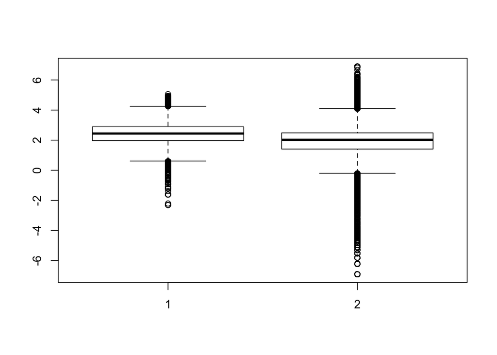

```r
boxplot(log(x1999), log(x2013))
```

Mean has gone down, but the spread has gone up. Oh, and the computer whines about taking the log of the negative values.